# UVU Offense

May 10, 2021

# Ball Movement and Scoring

During the 2020-21 season the **Utah Valley Wolverines** ran a motion offense that regularly moved the ball from one side of the court to the other and back. When timing was right and ball screen, cuts, and specific actions were executed the offense worked well.

This motion offense begged the question: *Was all the side to side movement and passing contributing to offensive success?*

A quick analysis might help us find out.

# The Gathering

Conference play started in January 2021 and I was asked to record each offensive possession and tally

- the number of passes once was the ball was in the half court.
- the number of times the ball switched sides of the half court.

These two stats are not tracked on ESPN or any college basketball platform that I am aware of so I would re-watch each game and manually track these occurrences.

# The Visuals

### Passing

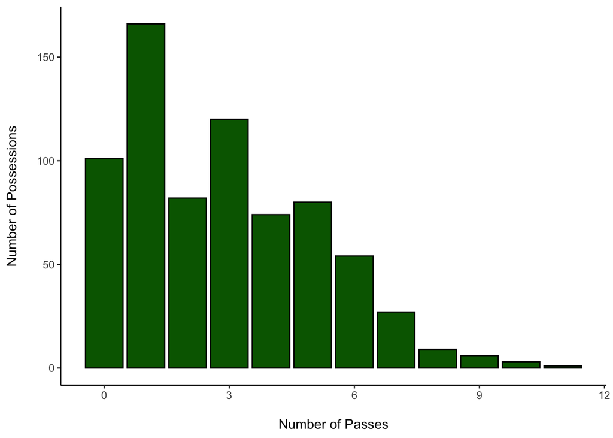

### Ball Movement

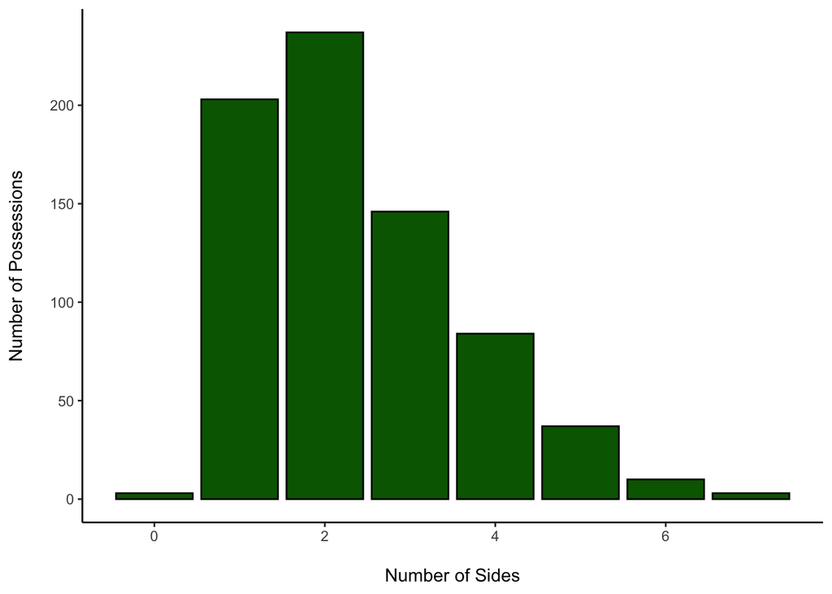

# The Scoring

### Passing vs. PPP

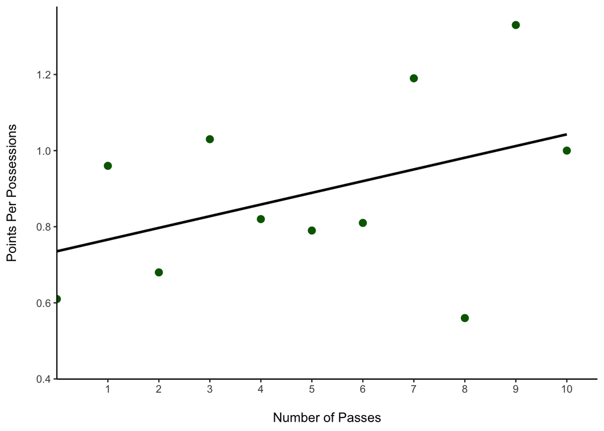

### Ball Movement vs. PPP

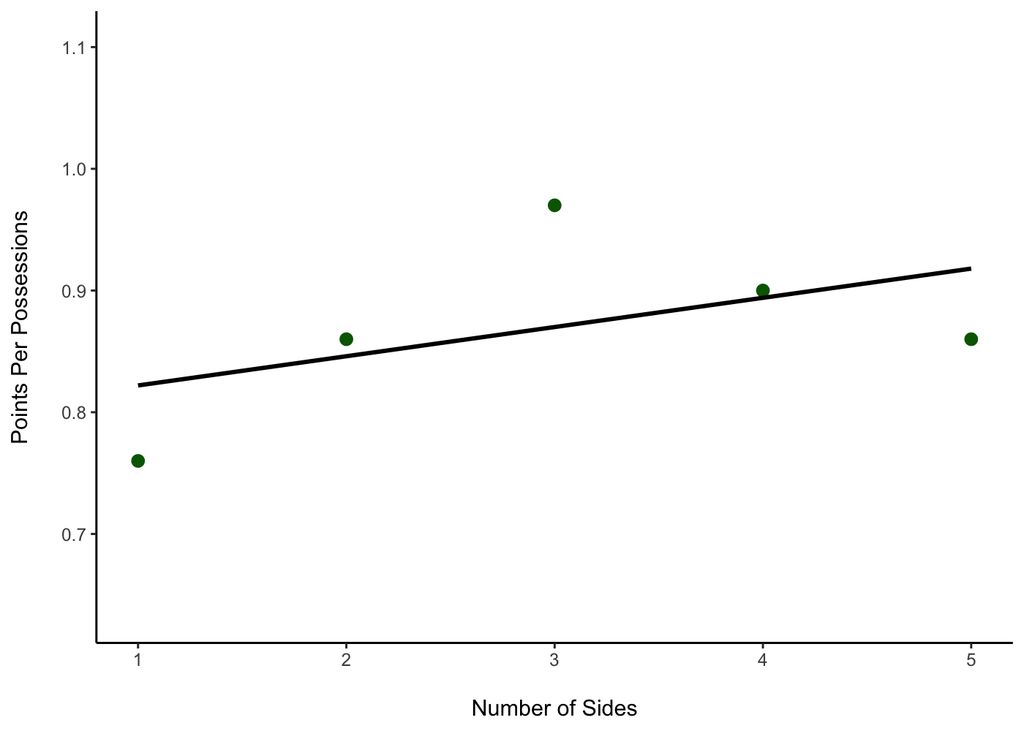

# Quick Takeaways

- On average an odd number of passes yielded more points per possession than an even number of passes.
- The number of sides displayed an nice bell-like curve in points per possession.